# Zad3_RyzykoOperacyjny

# 3 linia Com_Ban

## 3.1 Rozkład częstotliwości

**Show and hide code**

```r
rok_Com_Ban <- plik28 |>
  filter( linia == "Com_Ban") |>
  group_by(rok) |>
  summarize(liczba_zdarzen = n())

straty_Com_Ban <- plik28 |>
  filter(linia == "Com_Ban") |>
  group_by(rok) |>
  summarize(straty = sum(strata, na.rm = TRUE))

Com_Ban_summary <- merge(rok_Com_Ban, straty_Com_Ban, by = "rok")

kable(Com_Ban_summary, format = "html", caption = "Podsumowanie dla liniii Com_Ban") |>
  kable_styling(bootstrap_options = c("striped", "hover", "condensed"), full_width = F)
```

Podsumowanie dla liniii Com_Ban

| rok | liczba_zdarzen | straty |
| --- | --- | --- |
| 1989 | 6 | 158950.73 |
| 1990 | 7 | 131785.55 |
| 1991 | 8 | 305081.49 |
| 1992 | 2 | 2384.81 |
| 1993 | 9 | 217800.86 |
| 1994 | 6 | 198669.70 |
| 1995 | 9 | 246704.79 |
| 1996 | 7 | 140057.39 |
| 1997 | 9 | 225780.73 |
| 1998 | 6 | 76371.33 |
| 1999 | 5 | 157711.89 |
| 2000 | 5 | 124680.04 |
| 2001 | 5 | 160138.94 |
| 2002 | 8 | 162198.30 |
| 2003 | 4 | 20964.98 |
| 2004 | 8 | 347880.62 |
| 2005 | 10 | 277582.43 |
| 2006 | 7 | 192249.29 |
| 2007 | 2 | 24380.48 |
| 2008 | 6 | 120305.71 |
| 2009 | 5 | 169951.57 |
| 2010 | 8 | 122722.17 |
| 2011 | 5 | 47878.02 |
| 2012 | 7 | 129065.76 |
| 2013 | 7 | 94994.63 |
| 2014 | 9 | 159473.65 |
| 2015 | 7 | 198477.04 |
| 2016 | 5 | 102251.46 |
| 2017 | 6 | 90203.88 |
| 2018 | 2 | 58876.62 |
| 2019 | 6 | 210875.01 |
| 2020 | 4 | 99150.68 |
| 2021 | 3 | 65677.32 |
| 2022 | 6 | 163940.05 |
| 2023 | 8 | 202782.04 |

Początkowo dane zostały przefiltrowane dla liniii Com_Ban. Dla każdego roku obliczono liczbę zdarzeń oraz sumę strat.

**Show and hide code**

```r
mean_Com_Ban = mean(rok_Com_Ban$liczba_zdarzen)
sd_Com_Ban = sd(rok_Com_Ban$liczba_zdarzen)

mean_Com_Ban
```

```
[1] 6.2
```

**Show and hide code**

```r
sd_Com_Ban
```

```
[1] 2.083549
```

Średnia liczba zdarzeń to 6.2 a odchylenie standardowe 2.08. Na tej podstawie dopasowujemy rozkład dwumianowy, ponieważ gdy E(X) > D^2(X) to ta cecha wskazuje na ta taki rozkład.

## 3.2 Rozkład zdarzeń

Przyporządkowaliśmy rozkład dwumianowy, z parametrem size=100. Dla pewności, sprawdźmy jeszcze dopasowanie funkcją “fitdistr”:

**Show and hide code**

```r
size_value <- 100
Com_Ban_fit <- fitdist(rok_Com_Ban$liczba_zdarzen, "binom",fix.arg = list(size = size_value))
gofstat(Com_Ban_fit)
```

```
Chi-squared statistic:  1.731695
Degree of freedom of the Chi-squared distribution:  4
Chi-squared p-value:  0.7849525
   the p-value may be wrong with some theoretical counts < 5
Chi-squared table:
     obscounts theocounts
<= 4  6.000000   8.761605
<= 5  6.000000   5.520450
<= 6  7.000000   5.777938
<= 7  6.000000   5.128953
<= 8  5.000000   3.941375
> 8   5.000000   5.869679

Goodness-of-fit criteria
                               1-mle-binom
Akaike's Information Criterion    154.4561
Bayesian Information Criterion    156.0114
```

p-value wynosi 0,78 z tego powodu nie ma podstaw do odrzucenia hipotezy i możemy uznać rozkład dwumianowy za dobrze dopasowany. Dla pewności zobaczymy to jeszcze na wykresie:

**Show and hide code**

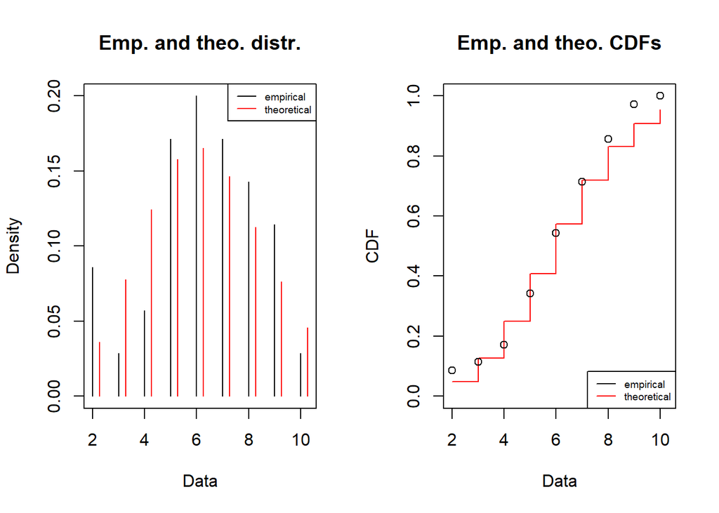

```r
plot(Com_Ban_fit)
```

Na czerwono widzimy rozkład teoretyczny, a na czarno empiryczny. Nie jest to dopasowanie idealne, ale podobne.

## 3.3 Rozkład strat

Teraz będziemy sprawdzać dopasowanie funkcją fitdist, tym razem sprawdzamy dopasowanie rozkładu dotkliwości strat do rozkładów lnorm, exp oraz gamma. Dopasowanie metodą momentów (mme)

**Show and hide code**

```r
Com_Ban2 <- fitdist(straty_Com_Ban$straty, method="mme","lnorm")
Com_Ban3 <- fitdist(straty_Com_Ban$straty, method="mme","exp")
Com_Ban4 <- fitdist(straty_Com_Ban$straty, method="mme","gamma")
names_test = c("lnorm", "exp", "gamma")

Result_Com_Ban<-gofstat(list(Com_Ban2, Com_Ban3, Com_Ban4), fitnames=names_test)
Result_Com_Ban$chisqpvalue
```

```
      lnorm         exp       gamma
0.030720010 0.002267045 0.366329458
```

**Show and hide code**

```r
Result_Com_Ban$adtest
```

```
         lnorm            exp          gamma
"not computed" "not computed" "not computed"
```

**Show and hide code**

```r
Result_Com_Ban$kstest
```

```
         lnorm            exp          gamma
"not rejected"     "rejected" "not rejected"
```

Ponownie zarówno rozkład lnorm jak i gamma mógłby być dobrym kandydatem. Z tego powodu, zobaczmy to na wykresie.

- Dla gammy:

**Show and hide code**

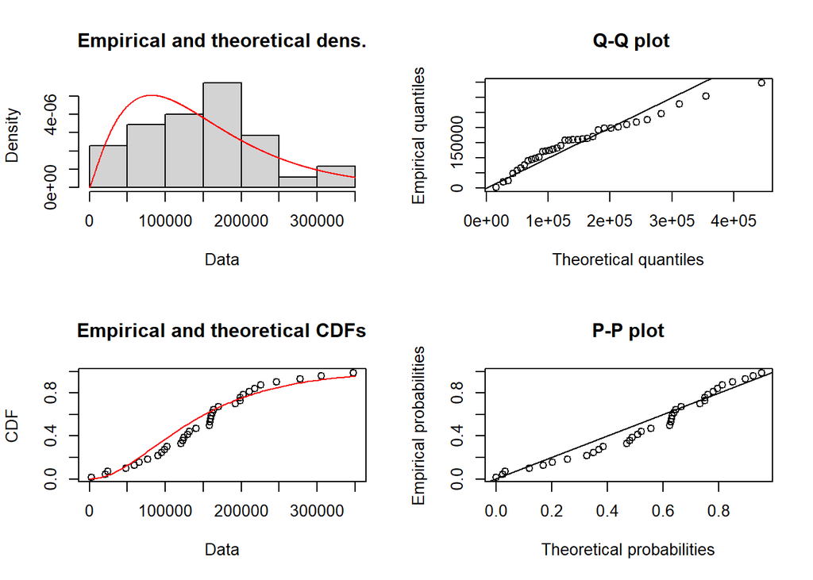

```r
plot(fitdist(straty_Com_Ban$straty, "gamma"))
```

- Dla lnorm:

**Show and hide code**

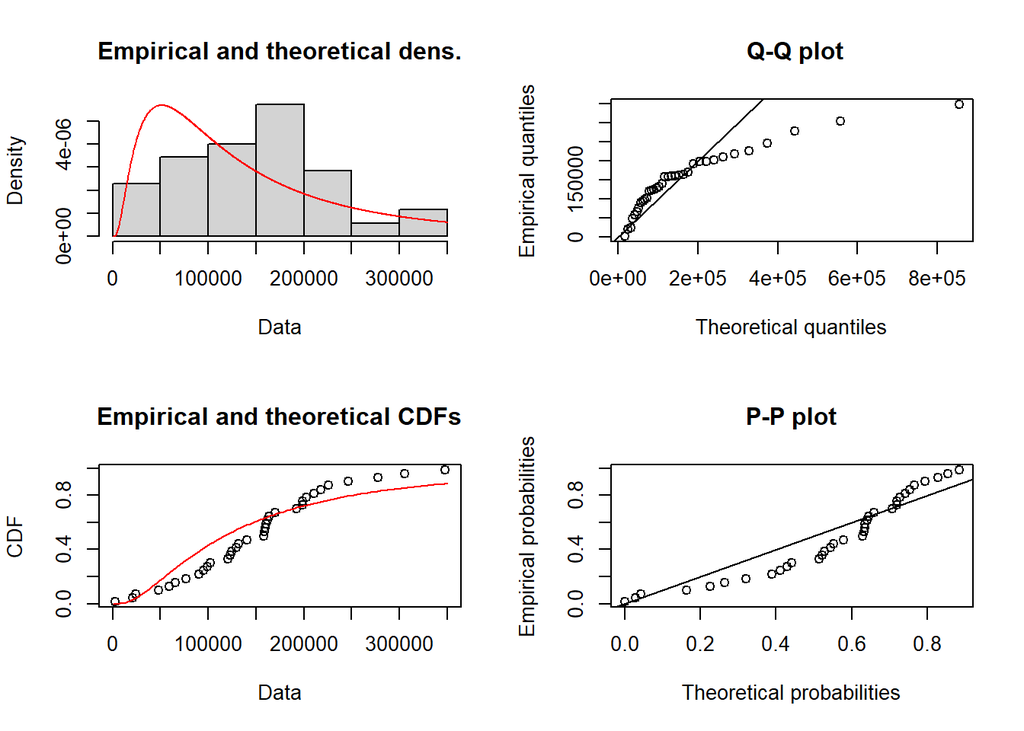

```r
plot(fitdist(straty_Com_Ban$straty, "lnorm"))
```

Na wykresie możemy zobaczyć, że rozkład teoretyczny gamma lepiej się dopasowuje, decydujemy się na wybór **gamma**.

## 3.4 Symulacja

**Show and hide code**

```r
set.seed(123)
binom_params <- Com_Ban_fit$estimate
prob_param <- binom_params["prob"]

gamma_params <- Com_Ban4$estimate
rate <- gamma_params["rate"]
shape <- gamma_params["shape"]
```

Parametry dopasowane metodą maksymalnej wiarygodności dla rozkładu dwumianowgo:  
prob_param = 0.06

Parametry dopasowania gamma:  
shape = 3.633469e+00  
rate = 2.441848e-05

**Show and hide code**

```r
n_sim <- 20000
size_param_binom <- 100

symulacje_Com_Ban <- replicate(n_sim, {
  liczba_zdarzen <- rbinom(1, size = size_param_binom, prob = prob_param)
  if (liczba_zdarzen == 0) return(0)
  sum(rexp(liczba_zdarzen, rate = rate))
})
```

Następnie na podstawie rozkładu symulowanego obliczamy OpVaR(99.9%) oraz OpES(99.9%).

**Show and hide code**

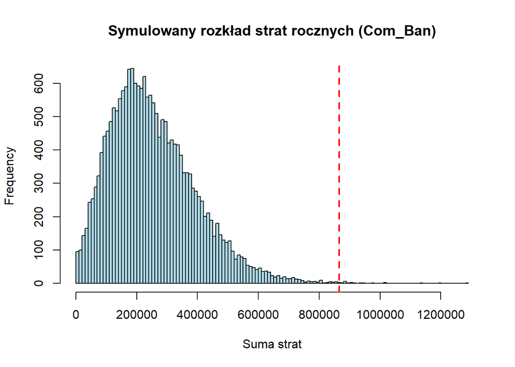

```r
OpVaR_999_Com_Ban <- quantile(symulacje_Com_Ban, 0.999)
OpES_999_Com_Ban <- mean(symulacje_Com_Ban[symulacje_Com_Ban > OpVaR_999_Com_Ban])

hist_Com_Ban <-hist(symulacje_Com_Ban, breaks = 100, col = "lightblue",
     main = "Symulowany rozkład strat rocznych (Com_Ban)",
     xlab = "Suma strat")
abline(v = OpVaR_999_Com_Ban, col = "red", lwd = 2, lty = 2)
```

**Show and hide code**

```r
cat("OpVaR (99.9%) = ", OpVaR_999_Com_Ban, "\n")
```

```
OpVaR (99.9%) =  865645
```

**Show and hide code**

```r
cat("OpES  (99.9%) = ", OpES_999_Com_Ban, "\n")
```

```
OpES  (99.9%) =  958487.2
```

Sporządziliśmy histogram symulowanego rozkładu strat, a na nim zaznaczona jest wartość OpVaR. Na osi X mamy wielkość straty, a na osi Y częstotliwość tych strat. Widzimy, że rozkład jest mocno prawoskośny z długimi ogonami. Większość strat wynosi ok. 200000.

# 4 linia Damage

## 4.1 Rozkład częstotliwości

**Show and hide code**

```r
rok_Damage <- plik28 |>
  filter( linia == "Damage") |>
  group_by(rok) |>
  summarize(liczba_zdarzen = n())

straty_Damage <- plik28 |>
  filter(linia == "Damage") |>
  group_by(rok) |>
  summarize(straty = sum(strata, na.rm = TRUE))

Damage_summary <- merge(rok_Damage, straty_Damage, by = "rok")

kable(Damage_summary, format = "html", caption = "Podsumowanie dla liniii Damage") |>
  kable_styling(bootstrap_options = c("striped", "hover", "condensed"), full_width = F)
```

Podsumowanie dla liniii Damage

| rok | liczba_zdarzen | straty |
| --- | --- | --- |
| 1989 | 12 | 56859.85 |
| 1990 | 12 | 500985.92 |
| 1991 | 7 | 718.76 |
| 1992 | 13 | 2497.02 |
| 1993 | 14 | 1664.38 |
| 1994 | 13 | 56223.42 |
| 1995 | 16 | 94143.53 |
| 1996 | 14 | 9758.27 |
| 1997 | 20 | 37783.26 |
| 1998 | 12 | 61151.44 |
| 1999 | 18 | 134973.96 |
| 2000 | 11 | 237238.63 |
| 2001 | 19 | 9121.87 |
| 2002 | 11 | 111071.95 |
| 2003 | 16 | 67282.75 |
| 2004 | 14 | 64988.23 |
| 2005 | 18 | 25373.58 |
| 2006 | 15 | 83408.61 |
| 2007 | 14 | 217268.76 |
| 2008 | 12 | 8890.47 |
| 2009 | 13 | 69844.02 |
| 2010 | 13 | 32792.30 |
| 2011 | 9 | 5041.97 |
| 2012 | 14 | 27640.58 |
| 2013 | 7 | 47756.07 |
| 2014 | 18 | 83507.94 |
| 2015 | 13 | 805.28 |
| 2016 | 16 | 6966.39 |
| 2017 | 16 | 748276.55 |
| 2018 | 17 | 72557.38 |
| 2019 | 16 | 263611.84 |
| 2020 | 14 | 84102.62 |
| 2021 | 16 | 60498.42 |
| 2022 | 17 | 51674.20 |
| 2023 | 13 | 48241.75 |

Dane zostały przefiltrowane dla liniii Damage. Dla każdego roku obliczono liczbę zdarzeń oraz sumę strat.

**Show and hide code**

```r
mean_Damage = mean(rok_Damage$liczba_zdarzen)
sd_Damage = sd(rok_Damage$liczba_zdarzen)

mean_Damage
```

```
[1] 14.08571
```

**Show and hide code**

```r
sd_Damage
```

```
[1] 3.042555
```

Średnia liczba zdarzeń to 14.09 a odchylenie standardowe 3.04. Na tej podstawie dopasowujemy rozkład dwumianowy, ponieważ gdy E(X) > D^2(X).

## 4.2 Rozkład zdarzeń

Przyporządkowaliśmy rozkład dwumianowy, z parametrem size=100. Dla pewności, sprawdźmy jeszcze dopasowanie funkcją “fitdistr”:

**Show and hide code**

```r
Damage_fit <- fitdist(rok_Damage$liczba_zdarzen, "binom",fix.arg = list(size = size_value))
gofstat(Damage_fit)
```

```
Chi-squared statistic:  3.311439
Degree of freedom of the Chi-squared distribution:  3
Chi-squared p-value:  0.3460537
   the p-value may be wrong with some theoretical counts < 5
Chi-squared table:
      obscounts theocounts
<= 11  5.000000   8.170138
<= 13 10.000000   7.460619
<= 14  6.000000   3.998426
<= 16  7.000000   7.032070
> 16   7.000000   8.338746

Goodness-of-fit criteria
                               1-mle-binom
Akaike's Information Criterion    180.3326
Bayesian Information Criterion    181.8879
```

p-value wynosi 0,35 z tego powodu nie ma podstaw do odrzucenia hipotezy zerowej i możemy uznać rozkład dwumianowy za dobrze dopasowany. Dla pewności zobaczymy to jeszcze na wykresie:

**Show and hide code**

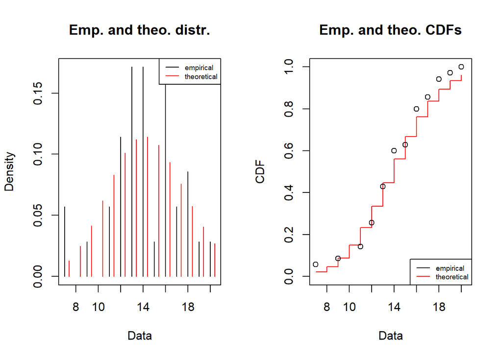

```r
plot(Damage_fit)
```

Widzimy, że zwłaszcza koło 14 rozkłady sporo się rozjeżdżają, ale poza nią są całkiem nieźle dopasowane do siebie.

## 4.3 Rozkład strat

Będziemy sprawdzać dopasowanie funkcją fitdist, sprawdzamy dopasowanie rozkładu dotkliwości strat do rozkładów lnorm, exp oraz gamma. Dopasowanie metodą momentów (mme)

**Show and hide code**

```r
Damage2 <- fitdist(straty_Damage$straty, method="mme","lnorm")
Damage3 <- fitdist(straty_Damage$straty, method="mme","exp")
Damage4 <- fitdist(straty_Damage$straty, method="mme","gamma")
names_test = c("lnorm", "exp", "gamma")

Result_Damage<-gofstat(list(Damage2, Damage3, Damage4), fitnames=names_test)
Result_Damage$chisqpvalue
```

```
       lnorm          exp        gamma
4.853593e-08 6.543133e-02 1.239760e-02
```

**Show and hide code**

```r
Result_Damage$adtest
```

```
         lnorm            exp          gamma
"not computed" "not computed" "not computed"
```

**Show and hide code**

```r
Result_Damage$kstest
```

```
         lnorm            exp          gamma
"not rejected" "not rejected" "not rejected"
```

- Dla gammy:

**Show and hide code**

[figure not shown]

```r
plot(fitdist(straty_Com_Ban$straty, "gamma"))
```

- Dla lnorm:

**Show and hide code**

[figure not shown]

```r
plot(fitdist(straty_Com_Ban$straty, "lnorm"))
```

- Dla exp:

**Show and hide code**

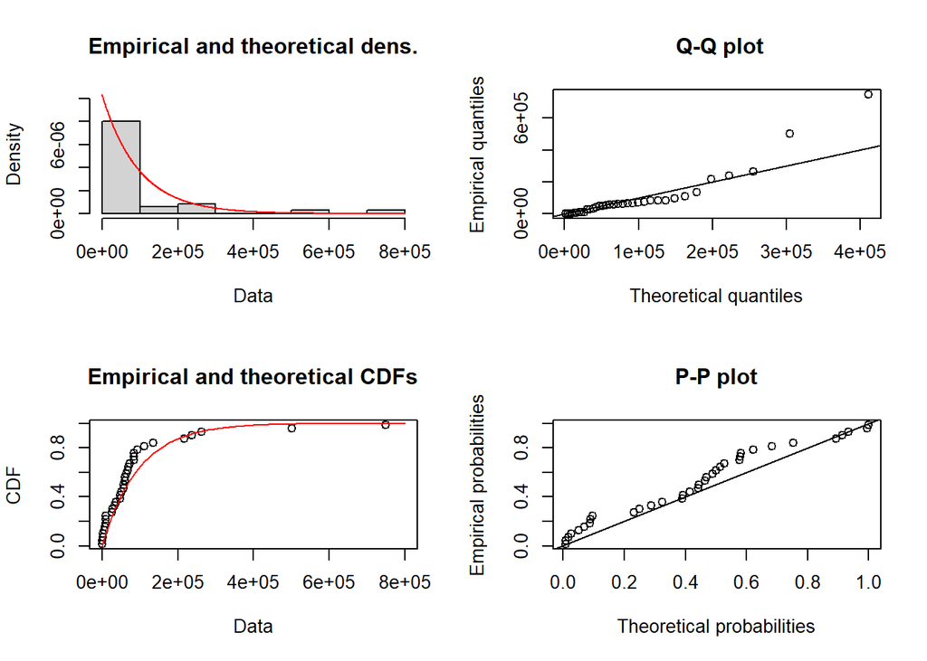

```r
plot(fitdist(straty_Damage$straty, "exp"))
```

Na wykresie możemy zobaczyć, że rozkład teoretyczny exp najlepiej się dopasowuje, decydujemy się na wybór **exp**.

## 4.4 Symulacja

Symulacja metodą Monte Carlo bazująca na dwóch wcześniej wybranych rozkładach - dwumianowy oraz exp.

**Show and hide code**

```r
set.seed(123)
binom_params2 <- Damage_fit$estimate
prob_param2 <- binom_params2["prob"]

exp_params2 <- Damage3$estimate
rate2 <- exp_params2["rate"]
```

Parametry dla rozkładu dwumianowgo:  
prob = 0.14

Parametry dopasowania exp:  
1.034058e-05

Symulujemy 20000 scenariuszy rocznych strat. Do każdej symulacji wylosowano liczbę zdarzeń z rozkładu dwumianowego oraz straty dla każdej szkody z rozkładu wykładniczego.

**Show and hide code**

```r
n_sim <- 20000
size_param_binom2 <- 100

symulacje_Damage <- replicate(n_sim, {
  liczba_zdarzen <- rbinom(1, size = size_param_binom2, prob = prob_param2)
  if (liczba_zdarzen == 0) return(0)
  sum(rexp(liczba_zdarzen, rate = rate2))
})
```

Następnie na podstawie rozkładu symulowanego obliczamy OpVaR(99.9%) oraz OpES(99.9%).

**Show and hide code**

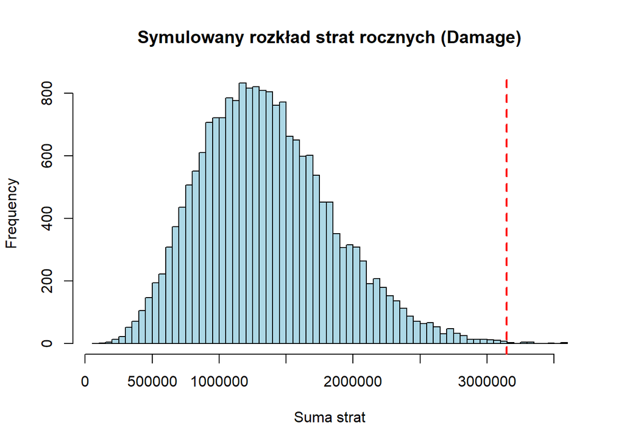

```r
OpVaR_999_Damage <- quantile(symulacje_Damage, 0.999)
OpES_999_Damage <- mean(symulacje_Damage[symulacje_Damage > OpVaR_999_Damage])

hist_Damage <- hist(symulacje_Damage, breaks = 100, col = "lightblue",
     main = "Symulowany rozkład strat rocznych (Damage)",
     xlab = "Suma strat")
abline(v = OpVaR_999_Damage, col = "red", lwd = 2, lty = 2)
```

**Show and hide code**

```r
cat("OpVaR (99.9%) = ", OpVaR_999_Damage, "\n")
```

```
OpVaR (99.9%) =  3144710
```

**Show and hide code**

```r
cat("OpES  (99.9%) = ", OpES_999_Damage, "\n")
```

```
OpES  (99.9%) =  3354405
```

# 5 linia Empl_Pract

## 5.1 Rozkład częstotliwości

**Show and hide code**

```r
rok_Empl_Pract <- plik28 |>
  filter( linia == "Empl_Pract") |>
  group_by(rok) |>
  summarize(liczba_zdarzen = n())

straty_Empl_Pract <- plik28 |>
  filter(linia == "Empl_Pract") |>
  group_by(rok) |>
  summarize(straty = sum(strata, na.rm = TRUE))



Damage_summary <- merge(rok_Empl_Pract, straty_Empl_Pract, by = "rok")

kable(Damage_summary, format = "html", caption = "Podsumowanie dla liniii Empl_Pract") |>
  kable_styling(bootstrap_options = c("striped", "hover", "condensed"), full_width = F)
```

Podsumowanie dla liniii Empl_Pract

| rok | liczba_zdarzen | straty |
| --- | --- | --- |
| 1989 | 208 | 6695888 |
| 1990 | 245 | 8395335 |
| 1991 | 216 | 7916551 |
| 1992 | 202 | 6941012 |
| 1993 | 223 | 8292797 |
| 1994 | 210 | 7495936 |
| 1995 | 205 | 7223664 |
| 1996 | 218 | 7994822 |
| 1997 | 194 | 6467671 |
| 1998 | 171 | 5746257 |
| 1999 | 237 | 8267316 |
| 2000 | 217 | 7043733 |
| 2001 | 210 | 7231522 |
| 2002 | 186 | 7242340 |
| 2003 | 219 | 8623152 |
| 2004 | 186 | 6879659 |
| 2005 | 251 | 8334410 |
| 2006 | 208 | 6892884 |
| 2007 | 239 | 8040672 |
| 2008 | 224 | 7663229 |
| 2009 | 207 | 7038882 |
| 2010 | 215 | 7998590 |
| 2011 | 240 | 8120605 |
| 2012 | 219 | 7681973 |
| 2013 | 239 | 8223851 |
| 2014 | 210 | 7308385 |
| 2015 | 198 | 7296573 |
| 2016 | 197 | 6855316 |
| 2017 | 198 | 6728837 |
| 2018 | 235 | 8300398 |
| 2019 | 234 | 8613890 |
| 2020 | 191 | 7175268 |
| 2021 | 244 | 7801358 |
| 2022 | 181 | 6043504 |
| 2023 | 197 | 7013732 |

Dane zostały przefiltrowane dla liniii Empl_Pract Dla każdego roku obliczono liczbę zdarzeń oraz sumę strat.

**Show and hide code**

```r
mean_Empl_Pract = mean(rok_Empl_Pract$liczba_zdarzen)
sd_Empl_Pract = sd(rok_Empl_Pract$liczba_zdarzen)

mean_Empl_Pract
```

```
[1] 213.5429
```

**Show and hide code**

```r
sd_Empl_Pract
```

```
[1] 20.07243
```

Średnia liczba zdarzeń to 213.54 a odchylenie standardowe 20.07. Na tej podstawie dopasowujemy rozkład ujemny dwumianowy, ponieważ gdy E(X) < D^2(X).

## 5.2 Rozkład zdarzeń

Przyporządkowaliśmy rozkład ujemny dwumianowy. Dla pewności, sprawdźmy jeszcze dopasowanie funkcją “fitdistr”:

**Show and hide code**

```r
Empl_Pract_fit <- fitdist(rok_Empl_Pract$liczba_zdarzen, "nbinom")
gofstat(Empl_Pract_fit)
```

```
Chi-squared statistic:  1.552438
Degree of freedom of the Chi-squared distribution:  4
Chi-squared p-value:  0.8173139
   the p-value may be wrong with some theoretical counts < 5
Chi-squared table:
       obscounts theocounts
<= 191  5.000000   4.602286
<= 198  5.000000   3.327920
<= 208  5.000000   6.339666
<= 216  5.000000   5.611379
<= 223  5.000000   4.561025
<= 239  6.000000   7.147161
> 239   4.000000   3.410564

Goodness-of-fit criteria
                               1-mle-nbinom
Akaike's Information Criterion     312.2797
Bayesian Information Criterion     315.3904
```

p-value wynosi 0,82 z tego powodu nie ma podstaw do odrzucenia hipotezy zerowej i możemy uznać rozkład ujemny dwumianowy za dobrze dopasowany. Dla pewności zobaczymy to jeszcze na wykresie:

**Show and hide code**

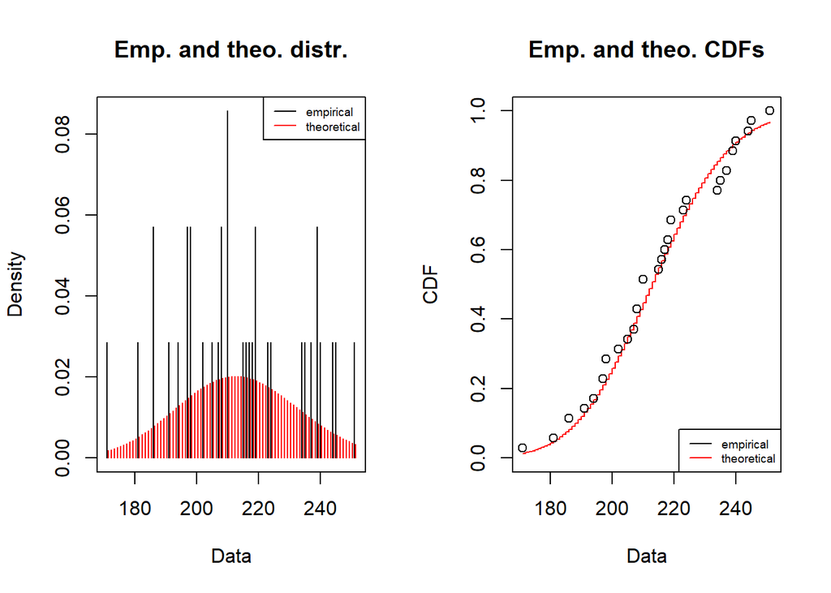

```r
plot(Empl_Pract_fit)
```

Dobrze przyjrzeć się w tym przypadku na wykres dystrybuanty. Widzimy, że dopasowanie jest nie najgorsze, rozjeżdża się przy ogonach, a zwłaszcza tym z prawej, ale w środku jest bardzo dobre.